# Exploring the BRFSS data

## Setup

### Load packages

```r
library(ggplot2)
library(dplyr)
library(ggmosaic)
library(gridExtra)
library(openintro)
library(rcompanion)
```

### Load data

```r
load("brfss2013.RData")
```

## Part 1: Data

The dataset used for this analysis is the Behavioral Risk Factor Surveillance System (BRFSS), an ongoing surveillance system designed to measure behavioral risk factors for the non-institutionalized adult population (18 years of age and older) residing in the US.

### What does this dataset contain?

The dataset contains uniform, state-specific **data on preventive health practices and risk behaviors that are linked to chronic diseases, injuries, and preventable infectious diseases** that affect the adult population.

Factors assessed by the BRFSS in 2013 include tobacco use, HIV/AIDS knowledge and prevention, exercise, immunization, health status, healthy days — health-related quality of life, health care access, inadequate sleep, hypertension awareness, cholesterol awareness, chronic health conditions, alcohol consumption, fruits and vegetables consumption, arthritis burden, and seatbelt use.

### Data Collection: what was the methodology used?

Since 2011, BRFSS conducts **telephone-based surveys** (both landline and cellular). Cell phones were added to the survey to maintain representativeness, coverage, and validity, since research shows that people who have only cellular phone service have a different demographic profile than those persons who have landline telephones. They tend to be younger, rent instead of own a home, are predominately Hispanic, and tend to be unmarried. There are attitudinal and behavioral differences between the two groups as well.

From 1980 until 2011 CDC used a statistical method called post stratification to weight BRFSS survey data to simultaneously adjust survey respondent data to known proportions of age, race and ethnicity, gender, geographic region, or other known characteristics of a population. Since 2011, CDC adopted a more sophisticated weighting method called **iterative proportional fitting, or raking**. Weighting makes the sample more representative of the population and adjusts for nonresponse bias.

Questionnaires are also performed in both **English and Spanish** in order to address spanish-speaker respondents as well.

**The population of study (non-institutionalized adult population residing in the US) is well represented by this methodology. This is an observational study that uses random sampling, therefore associations among variables can be generalized to the population. The study is not an experiment and doesn’t use random assignment, so the analysis cannot imply causation (only association).**

## Part 2: Research questions

### Research question 1:

Some people sarcastically say weight is not a problem if you have unlimited time and money. **Is there really a relationship between income and weight? And is this association the same for males or females?**

Growing rates of obesity is of great concern when it comes to health policies. It is important to identify what are the most affected segments of the population in order to create policies to prevent it.

### Research question 2:

**Is there a correlation between exercise and the risk of a heart attack? Could this be confounded by age?**

One of the most common preventive treatments for a heart attack is to exercise more. But do more people who were ever diagnosed with a heart attack exercise, in comparison with people that never were diagnosed? What role does age play in this correlation?

### Research question 3:

Sleep deprivation is commonly associated with memory issues and trouble with thinking and concentration. **Is there really an association between hours of sleep and difficulty concentrating or remembering?**

## Part 3: Exploratory data analysis

### Research question 1:

**What is the relationship between income and weight? Is this association the same for males or females?**

In order to tackle this question we start by selecting the variables we are going to use:

- X_bmi5 (Computed Body Mass Index)
- X_bmi5cat (Computed Body Mass Index Categories),
- X_incomg (Computed Income Categories),
- sex (Respondents Sex)

```r
weight <- brfss2013 %>%
  select(X_bmi5,
         X_bmi5cat,
         X_incomg,
         sex)
```

#### Summary statistics

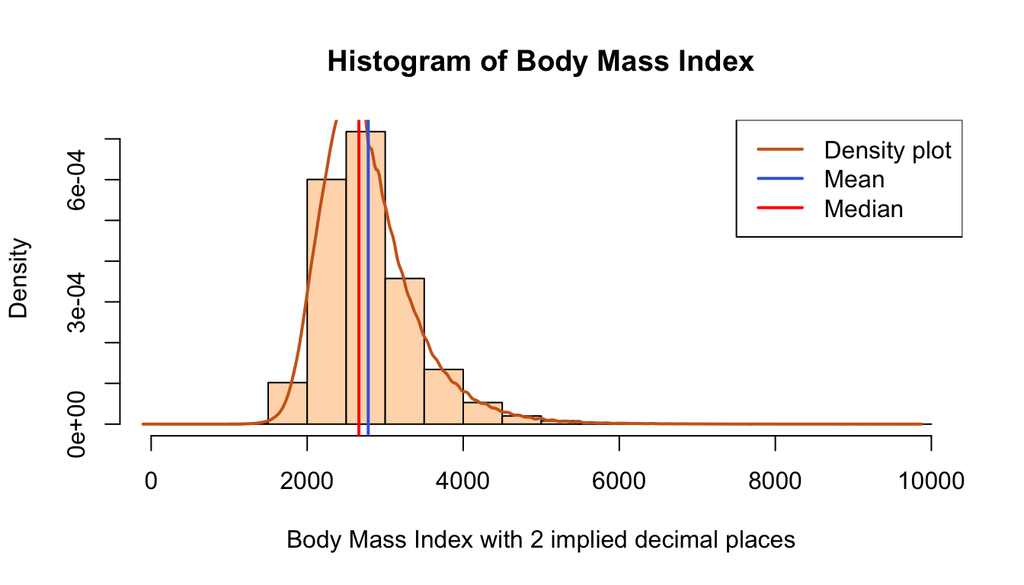

```r
hist(weight$X_bmi5,
     col = 'peachpuff',
     border = 'black',
     prob = TRUE,
     xlab = 'Body Mass Index with 2 implied decimal places',
     main = 'Histogram of Body Mass Index')
lines(density(weight$X_bmi5, na.rm = T), # density plot
      lwd = 2,
      col = 'chocolate3')
abline(v = mean(weight$X_bmi5, na.rm = T), # mean
       col = 'royalblue',
       lwd = 2)
abline(v = median(weight$X_bmi5, na.rm = T), # median
       col = 'red',
       lwd = 2)
legend(x = 'topright', # legend
       c('Density plot', 'Mean', 'Median'),
       col = c('chocolate3', 'royalblue', 'red'),
       lwd = c(2, 2, 2))
```

**Body Mass Index** has a mean of 2782 and a right-skewed distribution with a few outliers especially towards the higher end. The median is 2663 and the interquartile range is 714. There are 26727 missing values.

In a closer look, **outliers on the higher end seem consistent**. All values over 8000 are correctly classified as “obese” in the BMI Category variable.

On the lower end, however, we can see there are some **very unplausible values near 0**. Inspecting all values under 1000 we can see 6 records with BMI values under 10, indicating a mistake in the records The labels for the BMI category appear to have no relation to the BMI. In order to avoid working with unreliable data, in this case we are going to exclude those records from the dataset.

```r
weight[which(weight$X_bmi5 < 1000),] # errors
```

```
##        X_bmi5     X_bmi5cat                     X_incomg    sex
## 93722       1 Normal weight $15,000 to less than $25,000 Female
## 177693      1   Underweight                         <NA>   <NA>
## 180060      3 Normal weight            Less than $15,000   <NA>
## 180064      1   Underweight $15,000 to less than $25,000 Female
## 220825      5         Obese            Less than $15,000   Male
## 295934      1   Underweight            Less than $15,000 Female
```

```r
weight <- weight[-which(weight$X_bmi5 < 1000),] #eliminate errors
```

Following to that, we can now take a look at the distribution of the other variables of relevance for this question: **Income** and **Sex**.

```r
weight %>%
  group_by(X_incomg) %>%
  summarise(total = n()) %>%
  mutate(percentage = round(total / nrow(weight) * 100, 1))
```

```
## # A tibble: 6 x 3
##   X_incomg                      total percentage
##   <fct>                         <int>      <dbl>
## 1 Less than $15,000             52232      10.6
## 2 $15,000 to less than $25,000  76604      15.6
## 3 $25,000 to less than $35,000  48867       9.90
## 4 $35,000 to less than $50,000  61508      12.5
## 5 $50,000 or more              181131      36.8
## 6 <NA>                          71427      14.5
```

```r
weight %>%
  group_by(sex) %>%
  summarise(total = n()) %>%
  mutate(percentage = round(total / nrow(weight) * 100, 1))
```

```
## # A tibble: 3 x 3
##   sex     total percentage
##   <fct>   <int>      <dbl>
## 1 Male   201312       40.9
## 2 Female 290452       59.1
## 3 <NA>        5        0.
```

#### Analysis

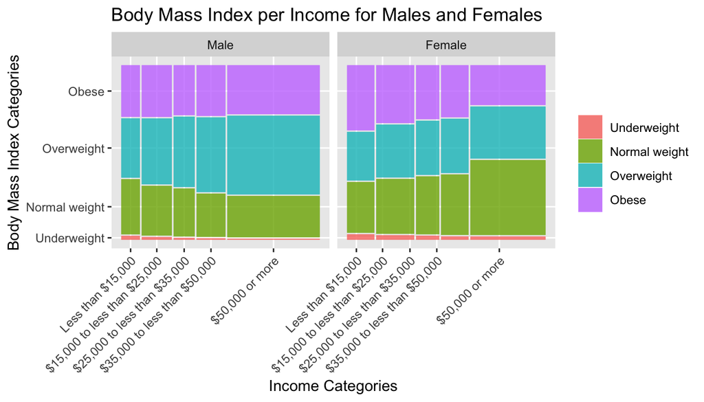

```r
# Plot preparation
weight <- weight %>%
  filter(!is.na(X_bmi5cat),
         !is.na(X_incomg),
         !is.na(sex))

# Analysis plot
ggplot(data = weight) +
  geom_mosaic(aes(x = product(X_bmi5cat, X_incomg), fill = X_bmi5cat)) +
  labs(x = 'Income Categories',
       y = 'Body Mass Index Categories',
       title = 'Body Mass Index per Income for Males and Females',
       fill = '') +
  theme(axis.text.x = element_text(angle = 45, hjust = 1)) +
  facet_grid(~sex)
```

There seem to be an association between weight and BMI that is dependent on sex. In both cases, **the proportion of Underweight individuals decreases as the income increases**. This relationship is more accentuaded for males.

As the income increases, the proportion of **male** Obese and Normal weight individuals also seem to decrease, and the proportion of Overweight indiduals increases.

For **females**, as the income increases, the proportion of Obese individuals decreases and the proportion of Normal weight individuals increases.

**The very marked patterns identified in the plots suggests there is a strong relationship between income and weight and since the patterns are very different for each sex, we can say this relationship is also dependent on gender.**

### Research question 2:

**Is there a correlation between exercise and the risk of a heart attack? Could this be confounded by age?**

For this question we will use the following variables:

- exerany2 (exercise in past 30 days),
- cvdinfr4 (ever diagnosed with heart attack),
- X_age_g (imputed age in six groups)

```r
heart <- brfss2013 %>%
  select(exerany2,
         cvdinfr4,
         X_age_g)
```

#### Summary Statistics

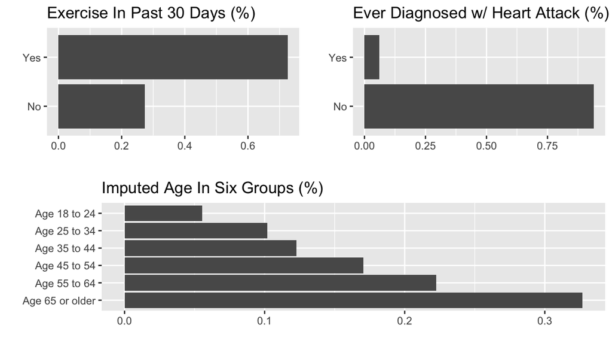

```r
grid.arrange(
  ggplot(heart, aes(x = exerany2)) +
    geom_bar(aes(y = (..count..)/sum(..count..))) +
    scale_x_discrete(limits = rev(levels(heart$exerany2))) +
    coord_flip() +
    labs(x = '',
         y = '',
         title = 'Exercise In Past 30 Days (%)'),
  ggplot(heart, aes(x = cvdinfr4)) +
    geom_bar(aes(y = (..count..)/sum(..count..))) +
    scale_x_discrete(limits = rev(levels(heart$cvdinfr4))) +
    coord_flip() +
    labs(x = '',
         y = '',
         title = 'Ever Diagnosed w/ Heart Attack (%)'),
  ggplot(heart, aes(x = X_age_g)) +
    geom_bar(aes(y = (..count..)/sum(..count..))) +
    scale_x_discrete(limits = rev(levels(heart$X_age_g))) +
    coord_flip() +
    labs(x = '',
         y = '',
         title = 'Imputed Age In Six Groups (%)'),
  layout_matrix = rbind(c(1,2),
                        c(3,3)))
```

In a first exploration of the data we can see that **more than 70% of the respondents exercised in the last 30 days**, and that **the majority of the respondents was never diagnosed with heart attack**. We can also see that **the number of respondents increases for each age group**, with fewer respondents that are younger and more respondents that are older.

There are 12 missing values for Age, 34029 missing values for Exercise and 2587 missing values for heart attack. The total number of records with missing values in any of the three variables is 36309, corresponding to 7.4% of the dataset. Removing those missing values will allow us to plot the categorical variables without a significative loss of information.

```r
# Removing missing values
heart <- heart %>%
  filter(!is.na(exerany2),
         !is.na(cvdinfr4),
         !is.na(X_age_g))
```

#### Analysis

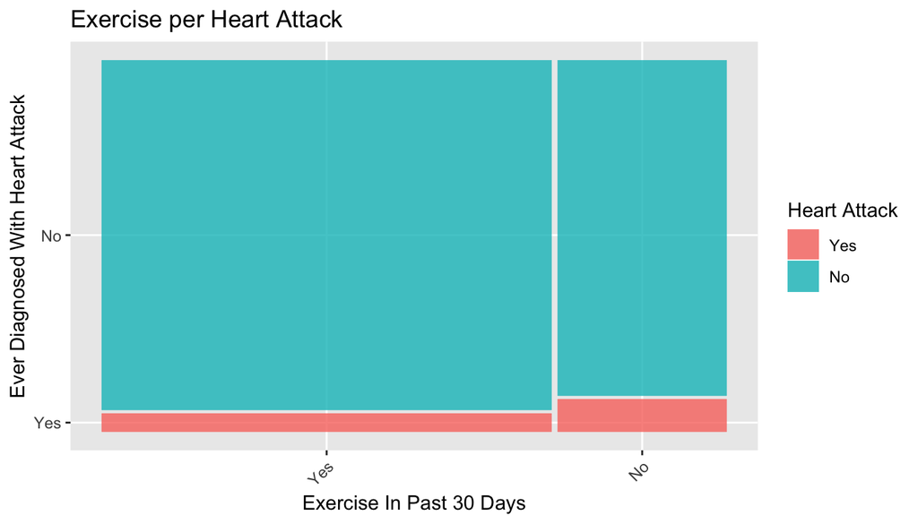

```r
heart %>%
  ggplot() +
  geom_mosaic(aes(x = product(cvdinfr4, exerany2), fill = cvdinfr4)) +
  labs(x = 'Exercise In Past 30 Days',
       y = 'Ever Diagnosed With Heart Attack',
       title = 'Exercise per Heart Attack',
       fill = 'Heart Attack') +
  theme(axis.text.x = element_text(angle = 45, hjust = 1))
```

When plotting Heart Attack with Excercise we can see there is an inverse correlation: **people who have had a heart attack tend to exercise less**. We might wonder about the direction of this correlation: would excercising prevents heart attacks or, on the contrarty, would having been diagnosed with a heart attack cause people to avoid excercising? Another interesting question in this case might be: could those two variables be affected by a confounding factor, such as age?

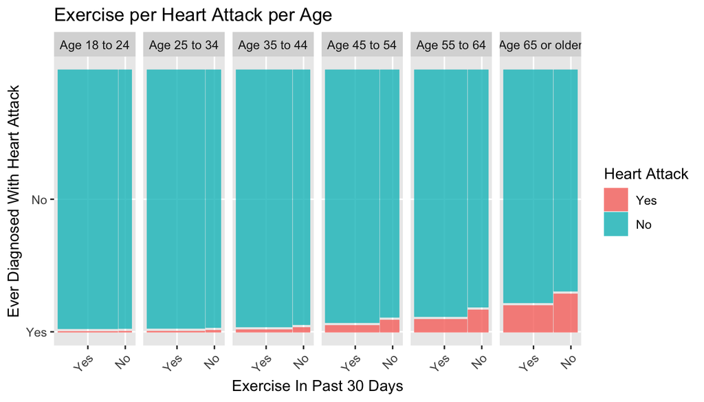

```r
heart %>%
  ggplot() +
  geom_mosaic(aes(x = product(cvdinfr4, exerany2), fill = cvdinfr4)) +
  labs(x = 'Exercise In Past 30 Days',
       y = 'Ever Diagnosed With Heart Attack',
       title = 'Exercise per Heart Attack per Age',
       fill = 'Heart Attack') +
  theme(axis.text.x = element_text(angle = 45, hjust = 1)) +
  facet_grid(~X_age_g)
```

When we add the variable Age to the analysis we can see that Age is a factor that influences both variables (excercise and heart attack). **As age increases, we can see the probability of heart attack also increases** (as indicated by the height of the coral bars). At the same time, **as age increases, people are less likelly to excercise** (as indicated by the width of the yes bars in each plot).

We can also see that the association identified in the former plot (People who have had a heart attack tend to exercise less) is still perceived for all age groups.

### Research question 3:

**Is there really an association between hours of sleep and difficulty concentrating or remembering?**

For exploring this association we will use the variables:

- sleptim1 (On average, how many hours of sleep do you get in a 24-hour period?),
- decide (difficulty concentrating or remembering)

```r
sleep <- brfss2013 %>%
  select(sleptim1,
         decide)
```

#### Outliers

We start by exploring our numeric variable, **sleptim1**, that reffers to the average number of hours the person sleeps per day. We can see some strange points where the reported number of sleep hours per day is superior to 24. On a closer look, there are 2 observations with values superior to 24. Those observations are not possible so we proceed to eliminate them.

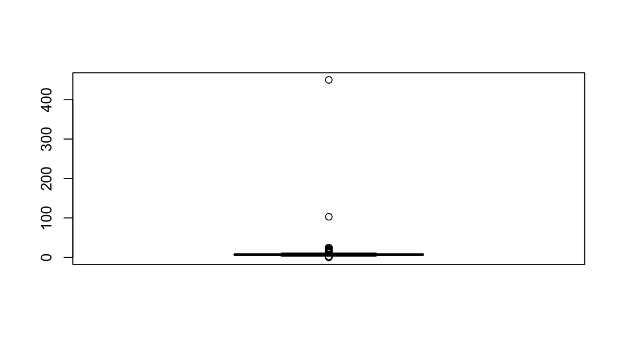

```r
boxplot(sleep$sleptim1) # boxplot
```

```r
sleep$sleptim1[which(sleep$sleptim1 > 24)] # identify observations
```

```
## [1] 103 450
```

```r
sleep <- sleep[-which(sleep$sleptim1 > 24),] # eliminate observations
```

#### Summary Statistics

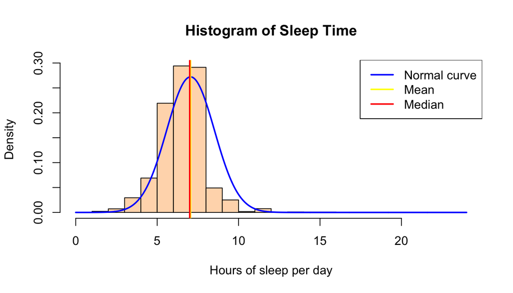

```r
plotNormalHistogram(sleep$sleptim1,
                    col = 'peachpuff',
                    border = 'black',
                    prob = TRUE,
                    xlab = 'Hours of sleep per day',
                    main = 'Histogram of Sleep Time')
abline(v = mean(sleep$sleptim1, na.rm = T), # mean
       col = 'yellow',
       lwd = 2)
abline(v = median(sleep$sleptim1, na.rm = T), # median
       col = 'red',
       lwd = 2)
legend(x = 'topright', # legend
       c('Normal curve', 'Mean', 'Median'),
       col = c('blue', 'yellow', 'red'),
       lwd = c(2, 2))
```

We can also see that approximatelly 10% of the respondents say they have ‘serious difficulty concentrating, remembering, or making decisions’.

```r
sleep %>%
  count(decide) %>%
  mutate(percent = n / nrow(sleep) * 100)
```

```
## # A tibble: 3 x 3
##   decide      n percent
##   <fct>   <int>   <dbl>
## 1 Yes     50647   10.3
## 2 No     428138   87.1
## 3 <NA>    12988    2.64
```

#### Analysis

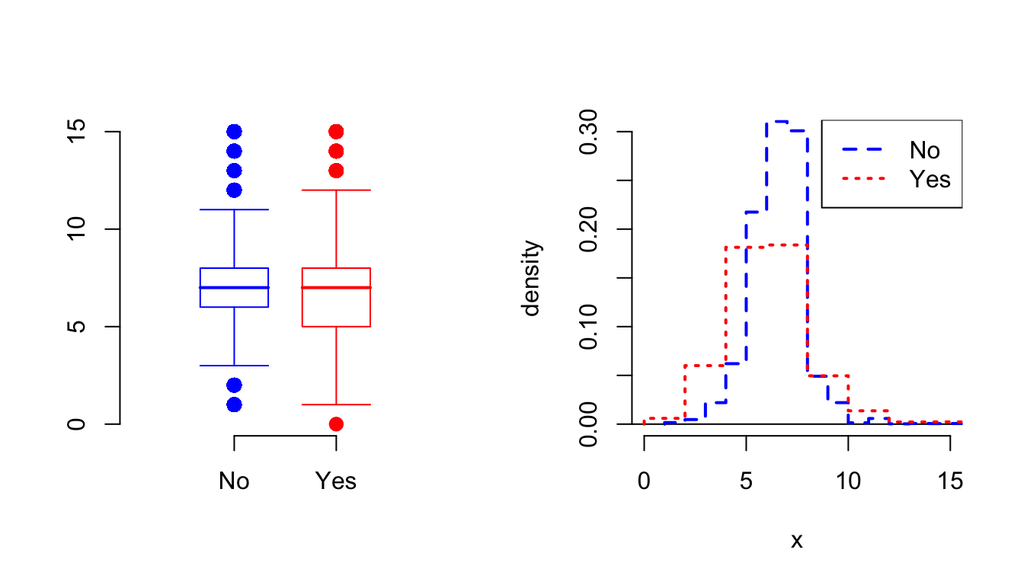

```r
par(mfrow=1:2)
# Boxplots
boxPlot(sleep$sleptim1[sleep$decide == 'No'],
        lcol = 'blue',
        col = 'blue',
        xlim = c(0, 3),
        ylim = c(0,15))
boxPlot(sleep$sleptim1[sleep$decide == 'Yes'],
        add = 2,
        axes = FALSE,
        lcol = 'red',
        col = 'red')
axis(1, at = 1:2, labels = c('No', 'Yes'))
# Histograms
histPlot(sleep$sleptim1[sleep$decide == 'No'],
         probability = TRUE,
         xlim = c(0, 15),
         ylim = c(0, 0.3),
         hollow = TRUE,
         border = 'blue',
         lty = 2,
         lwd = 2)
histPlot(sleep$sleptim1[sleep$decide == 'Yes'],
         probability = TRUE,
         add = TRUE,
         hollow = TRUE,
         lty = 3,
         border = 'red',
         lwd = 2)
legend('topright',
       col = c('blue', 'red'),
       lty = 2:3,
       lwd = 2,
       legend = c('No','Yes'))
```

Even thought mean and median are still very close for either people who have difficulty concentrating or people who don’t, the distribution of the number of sleep hours is much more concentrated for people who don’t report concentration issues.

When comparing people who don’t have difficulty concentrating and people who have, the mean number of sleep hours falls slightly from 7.09 to 6.75, while the median stays fixed at 7 hours. The difference is more perceived in the standard deviation that increases from 1.35 to 2.16 and the IQR that increases from 2 to 3.

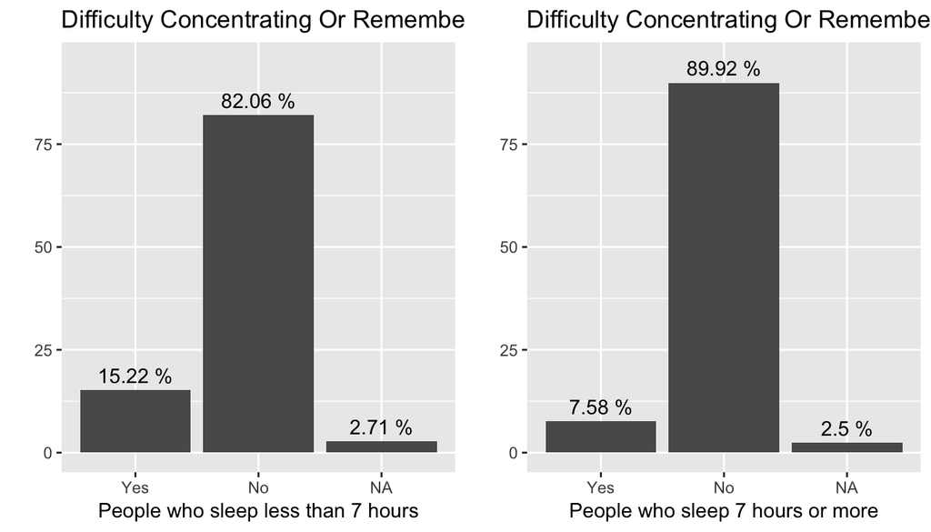

```r
grid.arrange(
  # less than 7 hours
  sleep %>%
    filter(sleptim1 < 7) %>%
    count(decide) %>%
    mutate(percent = n / sum(sleep$sleptim1 < 7, na.rm = T) * 100) %>%
    ggplot(aes(decide, percent)) +
    geom_col() +
    ylim(0, 95) +
    labs(x = 'People who sleep less than 7 hours',
         y = '',
         title = 'Difficulty Concentrating Or Remembering') +
    geom_text(aes(label = paste(round(percent, 2), '%'), vjust = -0.5)),
  # 7 or more hours
  sleep %>%
    filter(sleptim1 >= 7) %>%
    count(decide) %>%
    mutate(percent = n / sum(sleep$sleptim1 >= 7, na.rm = T) * 100) %>%
    ggplot(aes(decide, percent)) +
    geom_col() +
    ylim(0, 95) +
    labs(x = 'People who sleep 7 hours or more',
         y = '',
         title = 'Difficulty Concentrating Or Remembering') +
    geom_text(aes(label = paste(round(percent, 2), '%'), vjust = -0.5)),
  ncol = 2)
```

If we compare people who sleep less than 7 hours (the minimum recommended by the National Sleep Foundation) with those who sleep 7 hours or more, the difference becomes more apparent, with a **higher percentage of the former suffering from difficulty concentrating**.

We therefore can conclude there is indeed a **correlation between sleep deprivation and difficulty concentrating or remembering**.